# p8105_hw6_kx2173

#### Use 5,000 bootstrap samples:

Distribution of $\hat{r}^2$

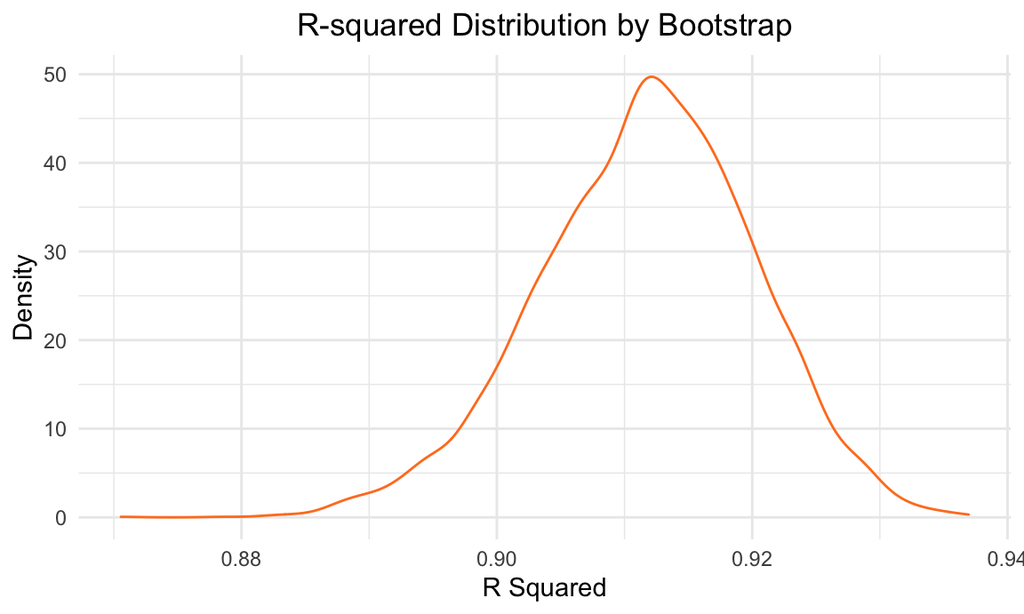

```r
bootstrap_rsquared = weather_df %>%
  modelr::bootstrap(n = 5000) %>%
  mutate(
    models = map(strap, ~lm(tmax ~ tmin, data = .x)),
    results = map(models, broom::glance)) %>%
  select(-strap, -models) %>%
  unnest(results) %>%
  select(.id, r.squared)

plot_rsquared = bootstrap_rsquared %>%
  ggplot(aes(x = r.squared)) +
  geom_density(color = "chocolate1") +
  labs(
    title = "R-squared Distribution by Bootstrap",
    x = "R Squared",
    y = "Density") +
  theme(plot.title = element_text(hjust = 0.5))

plot_rsquared
```

Distribution of $log(\hat{\beta}_0 \ast \hat{\beta}_1)$

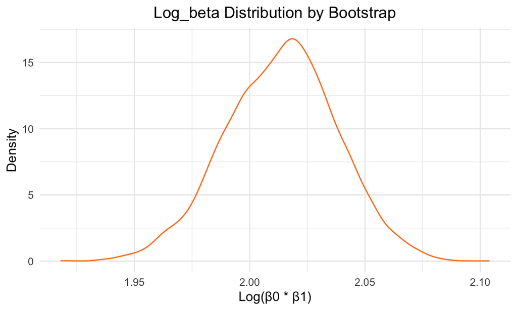

```r
bootstrap_logbeta = weather_df %>%
  modelr::bootstrap(n = 5000) %>%
  mutate(
    models = map(strap, ~lm(tmax ~ tmin, data = .x)),
    results = map(models, broom::tidy)) %>%
  unnest(results) %>%
  select(.id, term, estimate) %>%
  mutate(term = recode(term, `(Intercept)` = "beta0_hat", `tmin` = "beta1_hat")) %>%
  pivot_wider(
    names_from = "term",
    values_from = "estimate") %>%
  mutate(log_beta01 = log(beta0_hat * beta1_hat))

plot_logbeta = bootstrap_logbeta %>%
  ggplot(aes(x = log_beta01)) +
  geom_density(color = "chocolate1") +
  labs(
    title = "Log_beta Distribution by Bootstrap",
    x = "Log(β0 * β1)",
    y = "Density") +
  theme(plot.title = element_text(hjust = 0.5))

plot_logbeta
```

Describe the distribution of estimates: From these two plots, we can find that both r-squared and log(β0 * β1) are approximately normal distributed. The highest density value for r-squared is between 0.91 and 0.92, which is close to 1 so the data is well fitted with the regression model. The highest density value for log(β0 * β1) is between 2.00 and 2.025.

#### Provide 95% confidence interval for the estimates

```r
# R-squared confidence interval
ci_rsquared = bootstrap_rsquared %>%
  summarise(
    ci_lower = quantile(r.squared, 0.025),
    ci_upper = quantile(r.squared, 0.975)) %>%
  knitr::kable(caption = "95% CI for R-squared", digits = 2)

ci_rsquared
```

95% CI for R-squared

| ci_lower | ci_upper |
| --- | --- |
| 0.89 | 0.93 |

```r
# Log_beta confidence interval
ci_logbeta = bootstrap_logbeta %>%
  summarise(
    ci_lower = quantile(log_beta01, 0.025),
    ci_upper = quantile(log_beta01, 0.975)) %>%
  knitr::kable(caption = "95% CI for Log_beta", digits = 2)

ci_logbeta
```

95% CI for Log_beta

| ci_lower | ci_upper |
| --- | --- |
| 1.96 | 2.06 |